# VNI Analysis of RDM behavior

Hayley Brooks

##### Tips from template:

##### Set up

```r
rm(list=ls());  # clear environment
library(config);
config <- config::get();

vni_csv = file.path(config$path$data$clean,config$csvs$RDM_group_clean_csv);
mriBehClean = read.csv(vni_csv);


library(lme4);
library(lmerTest);
```

##### Subject information

```r
subIDs = unique(mriBehClean$subjectIndex);
nSub = length(subIDs);
sprintf("N = %s", nSub)
```

```
[1] "N = 48"
```

### Big Question

#### Does risk-taking change as a function of temporal context at three levels?

1. Immediate (past outcome)
2. Neighborhood (shifts)
3. Global (earnings)

### Trial-level model

##### Summary: Participants more likely to choose an option as its amount increases (no effect of ground expected value)

```r
model1_trialLevel = glmer(choice~ 0 + gainSC + altSC + grndEVscaled + (0+ gainSC + altSC|subjectIndex), data = mriBehClean, family = "binomial"); # model identical to VIC

summary(model1_trialLevel);
```

```
Generalized linear mixed model fit by maximum likelihood (Laplace  Approximation)
 [glmerMod]
 Family: binomial  ( logit )
Formula: choice ~ 0 + gainSC + altSC + grndEVscaled + (0 + gainSC + altSC |
    subjectIndex)
   Data: mriBehClean

     AIC      BIC   logLik deviance df.resid
  8058.9   8102.4  -4023.4   8046.9    10422

Scaled residuals:
    Min      1Q  Median      3Q     Max
-35.149  -0.444  -0.061   0.399 112.462

Random effects:
 Groups       Name   Variance Std.Dev. Corr
 subjectIndex gainSC  82.97    9.109
              altSC  326.92   18.081   -0.97
Number of obs: 10428, groups:  subjectIndex, 48

Fixed effects:
             Estimate Std. Error z value Pr(>|z|)
gainSC         16.118      1.922   8.387   <2e-16 ***
altSC         -41.078      3.823 -10.744   <2e-16 ***
grndEVscaled    6.990      5.438   1.285    0.199
---
Signif. codes:  0 ‘***’ 0.001 ‘**’ 0.01 ‘*’ 0.05 ‘.’ 0.1 ‘ ’ 1

Correlation of Fixed Effects:
            gainSC altSC
altSC       -0.014
grndEVscald -0.698 -0.697
```

##### Pull out “predicted” values from trial-level model and save as variable “pred” in mriBehClean dataframe

**Using “offset”, they’ll be applied inside the softmax with a weight of 1 every time, in effect accounting for our best current-trial predictions by directly entering those predictions on a trial-by-trial level. This lets us retain the binomial analysis structure vs using residuals (“resids”), which is much more accurate.**

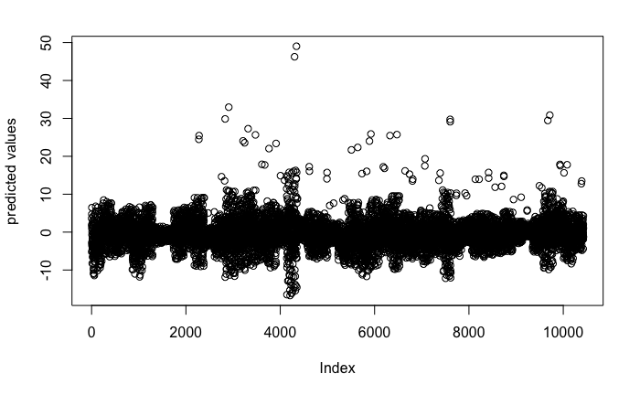

```r
mriBehClean$pred= predict(model1_trialLevel,type="link");
par(mfrow=c(1,1))
plot(mriBehClean$pred, ylab="predicted values");
```

#### 1) Immediate timescale: past outcome

##### Summary: There is a negative interaction between past outcome type and amount (plotted below) where risk-taking increases following a large loss (missed gain) and decreases following a large gain.

```r
model2_potc_amt = glmer(choice ~ 0 + poc1scaled + (1|subjectIndex), data=mriBehClean, family="binomial", offset=pred);
summary(model2_potc_amt);  # ns; AIC = 7592.9
```

```
Generalized linear mixed model fit by maximum likelihood (Laplace  Approximation)
 [glmerMod]
 Family: binomial  ( logit )
Formula: choice ~ 0 + poc1scaled + (1 | subjectIndex)
   Data: mriBehClean
 Offset: pred

     AIC      BIC   logLik deviance df.resid
  7592.9   7607.4  -3794.4   7588.9    10381

Scaled residuals:
    Min      1Q  Median      3Q     Max
-35.185  -0.443  -0.062   0.399 112.431

Random effects:
 Groups       Name        Variance  Std.Dev.
 subjectIndex (Intercept) 0.0009057 0.0301
Number of obs: 10383, groups:  subjectIndex, 48

Fixed effects:
            Estimate Std. Error z value Pr(>|z|)
poc1scaled 0.0004235  0.0835276   0.005    0.996
```

```r
model2_potc_type = glmer(choice ~ 0 + poc1type + (1|subjectIndex), data=mriBehClean, family="binomial", offset=pred);
summary(model2_potc_type); # ns; AIC =7592.1
```

```
Generalized linear mixed model fit by maximum likelihood (Laplace  Approximation)
 [glmerMod]
 Family: binomial  ( logit )
Formula: choice ~ 0 + poc1type + (1 | subjectIndex)
   Data: mriBehClean
 Offset: pred

     AIC      BIC   logLik deviance df.resid
  7592.1   7606.5  -3794.0   7588.1    10381

Scaled residuals:
    Min      1Q  Median      3Q     Max
-35.856  -0.443  -0.062   0.399 110.323

Random effects:
 Groups       Name        Variance  Std.Dev.
 subjectIndex (Intercept) 0.0009635 0.03104
Number of obs: 10383, groups:  subjectIndex, 48

Fixed effects:
         Estimate Std. Error z value Pr(>|z|)
poc1type  0.03812    0.04217   0.904    0.366
```

```r
model2_potc_amt_type_intxn = glmer(choice ~ 0 + poc1type*poc1scaled + (1|subjectIndex), data=mriBehClean, family="binomial", offset=pred);
summary(model2_potc_amt_type_intxn); # negative interaction between outcome type and amount; AIC = 7588.0
```

```
Generalized linear mixed model fit by maximum likelihood (Laplace  Approximation)
 [glmerMod]
 Family: binomial  ( logit )
Formula: choice ~ 0 + poc1type * poc1scaled + (1 | subjectIndex)
   Data: mriBehClean
 Offset: pred

     AIC      BIC   logLik deviance df.resid
  7588.0   7616.9  -3790.0   7580.0    10379

Scaled residuals:
    Min      1Q  Median      3Q     Max
-32.490  -0.441  -0.062   0.401 114.810

Random effects:
 Groups       Name        Variance Std.Dev.
 subjectIndex (Intercept) 0.003258 0.05708
Number of obs: 10383, groups:  subjectIndex, 48

Fixed effects:
                    Estimate Std. Error z value Pr(>|z|)
poc1type             0.12294    0.05584   2.202  0.02768 *
poc1scaled           0.22060    0.14008   1.575  0.11529
poc1type:poc1scaled -0.53975    0.19379  -2.785  0.00535 **
---
Signif. codes:  0 ‘***’ 0.001 ‘**’ 0.01 ‘*’ 0.05 ‘.’ 0.1 ‘ ’ 1

Correlation of Fixed Effects:
            pc1typ pc1scl
poc1scaled  -0.016
pc1typ:pc1s -0.453 -0.704
```

**Plot the interaction between past outcome amount and type:**  
**Outcome type is coded: 0 = safe; 1 = risky gain; -1 = risky loss (always $0)**

```r
m2coef = fixef(model2_potc_amt_type_intxn); # store all beta estimates

typeCoef = m2coef[1]; # past outcome type coefficient
amtCoef = m2coef[2]; # past outcome amount coefficient
intxnCoef = m2coef[3]; # past outcome type and amount interaction coefficient

## SAFE OUTCOMES
# Largest outcome when a participant rejected gamble = 30.49, scaled = .499918
# smallest outcome when a participant rejected gamble  = .78, scaled = .01278898
PgamPOCsafeSmall = 1/(1+exp(-1*( (typeCoef*0) + (amtCoef*.499918) + (intxnCoef*0*.499918) )));
# probability of gambling following a small, safe past outcome  = 0.5275424, 2.7% increase

PgamPOCsafeLarge = 1/(1+exp(-1*( (typeCoef*0) + (amtCoef*.01278898) + (intxnCoef*0*.01278898) )));
# probability of gambling following a large, safe past outcome  = 0.5007053

## GAINS
# largest outcome when a participant accepted gamble and won = $60.99, scaled = 1
# smallest outcome when a participant accepted gamble and won = $5.31, scaled = 0.08706345
  # technically, the minimum it could be 0 if participants missed an attn check
# medium outcome = $30.5, scaled = .5
# outcome when a participant accepted gamble and lost = $0

PgamPOCwinLarge = 1/(1+exp(-1*( (typeCoef*1) + (amtCoef*1) + (intxnCoef*1*1) )));
# probability of gambling following a large, risky win = 0.4511035, 5% decrease
PgamPOCwinSmall = 1/(1+exp(-1*( (typeCoef*1) + (amtCoef*0.08706345) + (intxnCoef*1*0.08706345) )));
# probability of gambling following a small, risky win = 0.5237715, a 2% increase
PgamPOCwinMedium = 1/(1+exp(-1*( (typeCoef*1) + (amtCoef*.5) + (intxnCoef*1*.5) )));
# probability of gambling following a medium, risky win = 0.4908425, a slight (<1%) decrease


## LOSSES (and MISSED GAINS)
PgamPOClossZero = 1/(1+exp(-1*( (typeCoef*-1) + (amtCoef*0) + (intxnCoef*-1*0) )));
# probability of gambling following a loss = 0.4693025, a 4.5% decrease

PgamPOClossSmallGain = 1/(1+exp(-1*( (typeCoef*-1) + (amtCoef*0.08706345) + (intxnCoef*-1*0.08706345) )));
# probability of gambling following a small missed gain = 0.4858174, a 1.4% decrease

PgamPOClossLargeGain = 1/(1+exp(-1*( (typeCoef*-1) + (amtCoef*1) + (intxnCoef*-1*1) )));
# probability of gambling following a large missed gain = 0.6541677, a 15.4% increase

PgamPOClossMediumGain = 1/(1+exp(-1*( (typeCoef*-1) + (amtCoef*.5) + (intxnCoef*-1*.5) )));
# probability of gambling following a medium missed gain = 0.5639559, a 6.3% increase


plot(c(PgamPOCwinSmall, PgamPOCwinMedium, PgamPOCwinLarge), type="l", col="green", lwd=3, ylim=c(0,1), main="Risk-taking changes as a function of past outcome type and amount", ylab="p(gamble)", xlab="past outcome", axes=F)
legend("topleft", legend=c("gain", "missed gain", "safe"), text.col = c("green", "red", "blue"), bty="n")
```

```r
axis(2)
axis(1, labels=c("small", "medium", "large"), at=c(1,2,3))
```

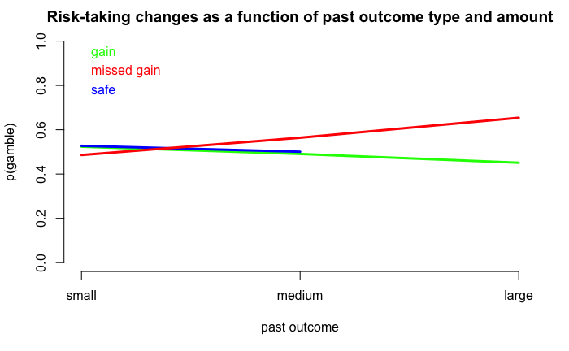

```r
lines(c(PgamPOCsafeSmall,PgamPOCsafeLarge), col="blue", lwd=3)
lines(c(PgamPOClossSmallGain,PgamPOClossMediumGain,PgamPOClossLargeGain), pch=16, col="red", lwd= 3)
```

```r
NA
NA
NA
NA
```

#### 2) Neighborhood timescale: Shifts

##### Summary: Risk-taking increases following a positive shift only and the effect is short-lasting (similar to VIC). Shift does not interact with run size or past outcome.

```r
model3_signed_shifts = glmer(choice~0 + shiftDiffsc + (1|subjectIndex), data=mriBehClean, family="binomial", offset=pred);
```

```
boundary (singular) fit: see ?isSingular
```

```r
summary(model3_signed_shifts); # signed shift difference, significant
```

```
Generalized linear mixed model fit by maximum likelihood (Laplace  Approximation)
 [glmerMod]
 Family: binomial  ( logit )
Formula: choice ~ 0 + shiftDiffsc + (1 | subjectIndex)
   Data: mriBehClean
 Offset: pred

     AIC      BIC   logLik deviance df.resid
  7660.7   7675.2  -3828.3   7656.7    10426

Scaled residuals:
    Min      1Q  Median      3Q     Max
-35.149  -0.445  -0.062   0.400 112.462

Random effects:
 Groups       Name        Variance  Std.Dev.
 subjectIndex (Intercept) 5.471e-15 7.396e-08
Number of obs: 10428, groups:  subjectIndex, 48

Fixed effects:
            Estimate Std. Error z value Pr(>|z|)
shiftDiffsc   1.0576     0.5027   2.104   0.0354 *
---
Signif. codes:  0 ‘***’ 0.001 ‘**’ 0.01 ‘*’ 0.05 ‘.’ 0.1 ‘ ’ 1
convergence code: 0
boundary (singular) fit: see ?isSingular
```

```r
model3_abs_shift = glmer(choice ~ 0 + shiftDiffscABs + (1|subjectIndex), data=mriBehClean, family="binomial", offset=pred);
summary(model3_abs_shift); # absolute shift difference, ns
```

```
Generalized linear mixed model fit by maximum likelihood (Laplace  Approximation)
 [glmerMod]
 Family: binomial  ( logit )
Formula: choice ~ 0 + shiftDiffscABs + (1 | subjectIndex)
   Data: mriBehClean
 Offset: pred

     AIC      BIC   logLik deviance df.resid
  7663.1   7677.6  -3829.6   7659.1    10426

Scaled residuals:
    Min      1Q  Median      3Q     Max
-35.165  -0.448  -0.062   0.398 112.457

Random effects:
 Groups       Name        Variance  Std.Dev.
 subjectIndex (Intercept) 0.0003501 0.01871
Number of obs: 10428, groups:  subjectIndex, 48

Fixed effects:
               Estimate Std. Error z value Pr(>|z|)
shiftDiffscABs   0.7096     0.5024   1.412    0.158
```

```r
model3_pos_neg_shifts = glmer(choice ~ 0 + shiftDiffscPOS + shiftDiffscNEG + (1|subjectIndex), data=mriBehClean, family="binomial", offset=pred);
summary(model3_pos_neg_shifts); # both positive and negative shift difference, only positive significant
```

```
Generalized linear mixed model fit by maximum likelihood (Laplace  Approximation)
 [glmerMod]
 Family: binomial  ( logit )
Formula: choice ~ 0 + shiftDiffscPOS + shiftDiffscNEG + (1 | subjectIndex)
   Data: mriBehClean
 Offset: pred

     AIC      BIC   logLik deviance df.resid
  7660.2   7682.0  -3827.1   7654.2    10425

Scaled residuals:
    Min      1Q  Median      3Q     Max
-35.167  -0.447  -0.062   0.399 112.458

Random effects:
 Groups       Name        Variance Std.Dev.
 subjectIndex (Intercept) 0.000396 0.0199
Number of obs: 10428, groups:  subjectIndex, 48

Fixed effects:
               Estimate Std. Error z value Pr(>|z|)
shiftDiffscPOS   1.9005     0.7318   2.597   0.0094 **
shiftDiffscNEG   0.3184     0.6856   0.464   0.6424
---
Signif. codes:  0 ‘***’ 0.001 ‘**’ 0.01 ‘*’ 0.05 ‘.’ 0.1 ‘ ’ 1

Correlation of Fixed Effects:
            shDPOS
shftDffsNEG -0.005
```

```r
m3_coef_posShift = fixef(model3_pos_neg_shifts)[1];

## Plot the effect of positive shift
# scaled shift amounts = 0 to .33 (or 0 to 20 nonscaled)
PgamPosShiftZero = 1/(1+exp(-1*( (m3_coef_posShift*0) ))); # should be .5
PgamPosShiftLarge = 1/(1+exp(-1*( (m3_coef_posShift*.33) )));
# probability of gambling following large positive shift = 0.6518448, a %15.2 increase
PgamPosShiftMedium = 1/(1+exp(-1*( (m3_coef_posShift*.16) )));
# probability of gambling following medium positive shift = 0.5754388, a %7.5 increase


plot(c(PgamPosShiftZero, PgamPosShiftMedium,PgamPosShiftLarge), type="l", lwd=3, col="blue", axes=F, ylab="p(gamble)", xlab="positive shift", main="risk taking as a function of positive shift")
axis(1, labels=c("no shift", "medium", "large"), at=c(1,2,3))
```

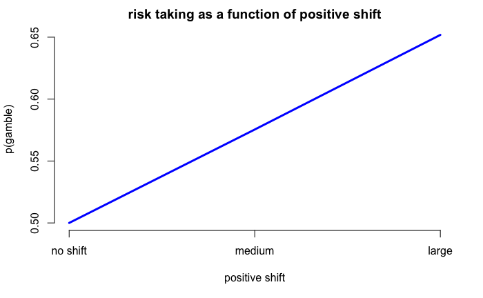

```r
axis(2)
```

```r
NA
NA
NA
```

#### How far back does shift effect go?

```r
# create new positive shift variable (n-1)
newMat = matrix(data=NA,nrow=nrow(mriBehClean), ncol=2);
newMat[,1] <- mriBehClean$shiftDiffscPOS; #take data from columns
newMat[2:nrow(newMat),1] <- newMat[1:(nrow(newMat)-1),1]; # removes first row, shifts everything up
newMat[1,1] <- NaN #put Nan in for first row (first trial for subject 1, bc there is no past trial)
newMat[,2]<-c(0,diff(mriBehClean$subjectIndex)); #put differences between subjectIndex into newvector, 1s show up when subject changes
newMat[newMat[,2]==1,]=NaN; #in newmtx, when diff = 1, replace with NaN, this replaces first trial with nan
mriBehClean$shiftDiffscPOS1 = newMat[,1];# add new vector to mriBehClean

# do the regressions
model3_pos_shift_howfarback = glmer(choice ~ 0 + shiftDiffscPOS + shiftDiffscPOS1 + (1|subjectIndex), data=mriBehClean, family="binomial", offset=pred);
summary(model3_pos_shift_howfarback); #short lasting, only trial directly after a shift
```

```
Generalized linear mixed model fit by maximum likelihood (Laplace  Approximation)
 [glmerMod]
 Family: binomial  ( logit )
Formula: choice ~ 0 + shiftDiffscPOS + shiftDiffscPOS1 + (1 | subjectIndex)
   Data: mriBehClean
 Offset: pred

     AIC      BIC   logLik deviance df.resid
  7587.4   7609.2  -3790.7   7581.4    10380

Scaled residuals:
    Min      1Q  Median      3Q     Max
-35.207  -0.448  -0.063   0.398 112.457

Random effects:
 Groups       Name        Variance Std.Dev.
 subjectIndex (Intercept) 0.002169 0.04657
Number of obs: 10383, groups:  subjectIndex, 48

Fixed effects:
                Estimate Std. Error z value Pr(>|z|)
shiftDiffscPOS    1.9151     0.7330   2.612  0.00899 **
shiftDiffscPOS1   0.6272     0.7554   0.830  0.40639
---
Signif. codes:  0 ‘***’ 0.001 ‘**’ 0.01 ‘*’ 0.05 ‘.’ 0.1 ‘ ’ 1

Correlation of Fixed Effects:
            shDPOS
shftDffPOS1 0.006
```

#### Does positive shift interact with previous run size or past outcome?

```r
# positive shift amount and run size before positive shift
model3_shift_pos_runSize = glmer(choice ~ 0 + shiftDiffscPOS*runSizePOS +(1|subjectIndex), data=mriBehClean, family="binomial", offset=pred);
summary(model3_shift_pos_runSize); # all betas ns
```

```
Generalized linear mixed model fit by maximum likelihood (Laplace  Approximation)
 [glmerMod]
 Family: binomial  ( logit )
Formula: choice ~ 0 + shiftDiffscPOS * runSizePOS + (1 | subjectIndex)
   Data: mriBehClean
 Offset: pred

     AIC      BIC   logLik deviance df.resid
  7661.6   7690.6  -3826.8   7653.6    10424

Scaled residuals:
    Min      1Q  Median      3Q     Max
-35.184  -0.449  -0.062   0.398 112.456

Random effects:
 Groups       Name        Variance  Std.Dev.
 subjectIndex (Intercept) 0.0007681 0.02771
Number of obs: 10428, groups:  subjectIndex, 48

Fixed effects:
                          Estimate Std. Error z value Pr(>|z|)
shiftDiffscPOS             1.05014    2.51296   0.418    0.676
runSizePOS                 0.02344    0.02711   0.865    0.387
shiftDiffscPOS:runSizePOS -0.03565    0.24334  -0.147    0.884

Correlation of Fixed Effects:
            shDPOS rnSPOS
runSizePOS  -0.086
shDPOS:SPOS -0.809 -0.456
```

```r
# both positive and negative shift and run size before positive and negative shift
model3_shift_pos_neg_runSize = glmer(choice ~ 0 + shiftDiffscPOS*runSizePOS + shiftDiffscNEG*runSizeNEG + (1|subjectIndex), data=mriBehClean, family="binomial", offset=pred);
summary(model3_shift_pos_neg_runSize); #all betas ns
```

```
Generalized linear mixed model fit by maximum likelihood (Laplace  Approximation)
 [glmerMod]
 Family: binomial  ( logit )
Formula:
choice ~ 0 + shiftDiffscPOS * runSizePOS + shiftDiffscNEG * runSizeNEG +
    (1 | subjectIndex)
   Data: mriBehClean
 Offset: pred

     AIC      BIC   logLik deviance df.resid
  7664.0   7714.8  -3825.0   7650.0    10421

Scaled residuals:
    Min      1Q  Median      3Q     Max
-35.186  -0.449  -0.063   0.397 112.457

Random effects:
 Groups       Name        Variance  Std.Dev.
 subjectIndex (Intercept) 0.0008075 0.02842
Number of obs: 10428, groups:  subjectIndex, 48

Fixed effects:
                          Estimate Std. Error z value Pr(>|z|)
shiftDiffscPOS             1.05042    2.50193   0.420    0.675
runSizePOS                 0.02345    0.02711   0.865    0.387
shiftDiffscNEG             2.95593    2.30250   1.284    0.199
runSizeNEG                 0.03491    0.02650   1.317    0.188
shiftDiffscPOS:runSizePOS -0.03569    0.24261  -0.147    0.883
shiftDiffscNEG:runSizeNEG -0.08937    0.25421  -0.352    0.725

Correlation of Fixed Effects:
            shDPOS rnSPOS shDNEG rnSNEG sDPOS:
runSizePOS  -0.086
shftDffsNEG  0.008 -0.002
runSizeNEG   0.000  0.002 -0.054
shDPOS:SPOS -0.808 -0.457 -0.006  0.000
shDNEG:SNEG -0.006  0.001 -0.827  0.547  0.005
```

```r
# Does positive shift interact with past outcome?
model3_posShift_potc_intxn = glmer(choice ~ 0 + shiftDiffscPOS*poc1scaled + (1|subjectIndex), data=mriBehClean, family="binomial", offset=pred);
summary(model3_posShift_potc_intxn); #all betas ns
```

```
Generalized linear mixed model fit by maximum likelihood (Laplace  Approximation)
 [glmerMod]
 Family: binomial  ( logit )
Formula: choice ~ 0 + shiftDiffscPOS * poc1scaled + (1 | subjectIndex)
   Data: mriBehClean
 Offset: pred

     AIC      BIC   logLik deviance df.resid
  7589.2   7618.2  -3790.6   7581.2    10379

Scaled residuals:
    Min      1Q  Median      3Q     Max
-34.795  -0.445  -0.062   0.399 113.189

Random effects:
 Groups       Name        Variance Std.Dev.
 subjectIndex (Intercept) 0.001434 0.03787
Number of obs: 10383, groups:  subjectIndex, 48

Fixed effects:
                          Estimate Std. Error z value Pr(>|z|)
shiftDiffscPOS             1.15538    1.06976   1.080    0.280
poc1scaled                -0.02527    0.08510  -0.297    0.767
shiftDiffscPOS:poc1scaled  5.30092    5.37305   0.987    0.324

Correlation of Fixed Effects:
            shDPOS pc1scl
poc1scaled   0.026
shftDfPOS:1 -0.727 -0.107
```

#### 3) Global timescale: Cumulative earnings (and trial)

```r
model4_earnings_trial = glmer(choice~0 + earningsNormalized + trialSC + (1|subjectIndex), data=mriBehClean, family="binomial", offset=pred);
summary(model4_earnings_trial); # both significant, betas similar size but opposite valence, AIC = 7657.1
```

```
Generalized linear mixed model fit by maximum likelihood (Laplace  Approximation)
 [glmerMod]
 Family: binomial  ( logit )
Formula: choice ~ 0 + earningsNormalized + trialSC + (1 | subjectIndex)
   Data: mriBehClean
 Offset: pred

     AIC      BIC   logLik deviance df.resid
  7657.1   7678.9  -3825.6   7651.1    10425

Scaled residuals:
    Min      1Q  Median      3Q     Max
-35.826  -0.446  -0.062   0.392 108.218

Random effects:
 Groups       Name        Variance Std.Dev.
 subjectIndex (Intercept) 0.003929 0.06268
Number of obs: 10428, groups:  subjectIndex, 48

Fixed effects:
                   Estimate Std. Error z value Pr(>|z|)
earningsNormalized   2.3615     0.8072   2.926  0.00344 **
trialSC             -2.2802     0.7964  -2.863  0.00419 **
---
Signif. codes:  0 ‘***’ 0.001 ‘**’ 0.01 ‘*’ 0.05 ‘.’ 0.1 ‘ ’ 1

Correlation of Fixed Effects:
        ernngN
trialSC -0.998
```

```r
# pull and store coefficients
m4_coef_trial_Earn = fixef(model4_earnings_trial);
earnCoef = m4_coef_trial_Earn[1];
triCoef = m4_coef_trial_Earn[2];

# plot a couple of subs' earnings and pgamble over the task as a function of earnings and trial
sub1 = mriBehClean[mriBehClean$subjectIndex==7,];
PgamSub1EarnTrial =1/(1+exp(-1*( (triCoef*sub1$trialSC) + (earnCoef*sub1$earningsNormalized) )));

sub2 = mriBehClean[mriBehClean$subjectIndex==35,];
PgamSub2EarnTrial =1/(1+exp(-1*( (triCoef*sub2$trialSC) + (earnCoef*sub2$earningsNormalized) )))

sub3 = mriBehClean[mriBehClean$subjectIndex==52,];
PgamSub3EarnTrial =1/(1+exp(-1*( (triCoef*sub3$trialSC) + (earnCoef*sub3$earningsNormalized) )))

sub4 = mriBehClean[mriBehClean$subjectIndex==15,];
PgamSub4EarnTrial =1/(1+exp(-1*( (triCoef*sub4$trialSC) + (earnCoef*sub4$earningsNormalized) )))

sub5 = mriBehClean[mriBehClean$subjectIndex==28,];
PgamSub5EarnTrial =1/(1+exp(-1*( (triCoef*sub5$trialSC) + (earnCoef*sub5$earningsNormalized) )))

plot(PgamSub1EarnTrial, type="l", col="darkgreen", lwd=3, ylim=c(.4,.6), ylab="p(gamble)", xlab="trial", main="risk taking as a function\n of trial and earnings")
lines(PgamSub2EarnTrial, col="darkred", lwd=3);
```

```r
lines(PgamSub3EarnTrial, col="darkblue", lwd=3);
lines(PgamSub4EarnTrial, col="darkorange", lwd=3);
```

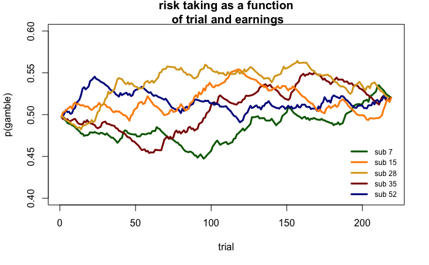

```r
lines(PgamSub5EarnTrial, col="goldenrod", lwd=3);
legend("bottomright", legend=c("sub 7","sub 15", "sub 28" ,"sub 35", "sub 52"), lty = 1, lwd=3, bty="n", col=c("darkgreen", "darkorange", "goldenrod", "darkred","darkblue"), cex=.75)
```

```r
plot(sub1$earningsNormalized,type="l", col="darkgreen", lwd=3, xlab="trial", ylab="earnings (normalized)", main="earnings across the task")
lines(sub2$earningsNormalized, col="darkred", lwd=3)
```

```r
lines(sub3$earningsNormalized, col="darkblue", lwd=3)
lines(sub4$earningsNormalized, col="darkorange", lwd=3)
```

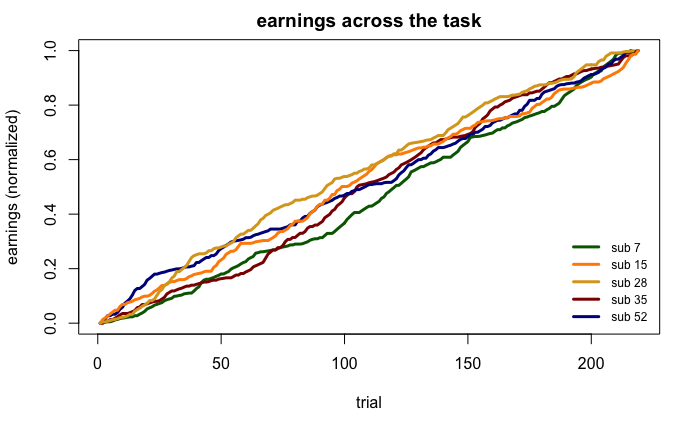

```r
lines(sub5$earningsNormalized, col="goldenrod", lwd=3)

legend("bottomright", legend=c("sub 7","sub 15", "sub 28" ,"sub 35", "sub 52"), lty = 1, lwd=3, bty="n", col=c("darkgreen", "darkorange", "goldenrod", "darkred","darkblue"), cex=.75)
```

```r
# Model and plot with interaction term between earnings and trials
    # Interaction was trending here, so I am not sure how much to focus on this. The above model and plots seem more informative.
# model4_earnings_trial_intxn = glmer(choice~0 + earningsNormalized*trialSC + (1|subjectIndex), data=mriBehClean, family="binomial", offset=pred);
# summary(model4_earnings_trial_intxn); # interaction trending, AIC = 7655.5
#
# m4_coef_trialEarn_intxn = fixef(model4_earnings_trial_intxn);
# earnCoef = m4_coef_trialEarn_intxn[1];
# triCoef = m4_coef_trialEarn_intxn[2];
# m4intxnCoef = m4_coef_trialEarn_intxn[3];

# Plot
# earnings= rep(c(0,.5,1), times =3)
# trials = rep(c(.005, .5, 1), each =3)
#
# PgamEarnings = 1/(1+exp(-1*(earnCoef*earnings) ));
# PgamTrial = 1/(1+exp(-1*(triCoef*trials) ));
# PgamEarnTrialIntxn = 1/(1+exp(-1*(earnCoef*earnings) + (triCoef*trials) + m4intxnCoef*earnings*trials ))

# plot(PgamEarnTrialIntxn[1:3], type="l", lwd=3, ylim = c(.5,1), ylab="p(gamble)",xlab="earnings", axes=F, col="orange")
# lines(PgamEarnTrialIntxn[4:6], lwd = 3, col="darkorange2")
# lines(PgamEarnTrialIntxn[7:9], lwd = 3, col="darkorange4")
# axis(2)
# axis(1, at=c(1,2,3), labels=c("small", "medium", "large"))
# legend("bottomright", legend=c("t=1", "t=109", "t=219"), text.col = c("orange", "darkorange2", "darkorange4"), bty="n")
#
```

Plot cumulative earnings for all participants across the task

```r
plot(mriBehClean$earningsNormalized[mriBehClean$subjectIndex==1], type = "l",lwd = 2, ylim = c(0,1), xlim= c(0,219), main = "Earnings (normalized) across task\n each line is a participant", ylab = "earnings", xlab="trial number", axes=FALSE)
axis(1, label = c(1, 219), at = c(1,219), tck = 0, lwd = 3)
```

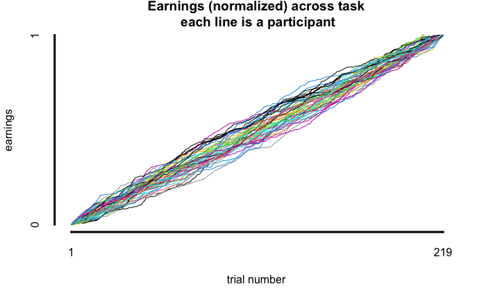

```r
axis(2, label = c(0, 1), at = c(0,1), tck = 0, lwd =3)
for(s in 2:nSub){
  points(mriBehClean$earningsNormalized[mriBehClean$subjectIndex==s], type="l", lwd = 1, col = mriBehClean$subjectIndex/.2+s)
};
```